# Assigment - Naive Bayes DIY

Qiwen Chen - Author

Thanh Hung Lê - Reviewer

31 March, 2021

## Business Understanding

In 2017, the Pew Research Center indicated that “roughly 4/10 Americans have personally experienced online harassment”. This illustrates the importance of detecting online hate speech. Naives Bayes techniques can be used to detect hate speech to further intervene the conversations.

## Data Understanding

The data that I will use comes from the Reddit Hate Speech Collection. It contains a set of Reddit conversations that are manually labeled as hate or non-hate speech with intervention responses by Mechanical Turk workers. In the following, the dataset is read, and I find out there is not needed data, so I remove column 1 and 4.

```r
url <- "https://raw.githubusercontent.com/HAN-M3DM-Data-Mining/assignments/master/datasets/NB-reddit-hate-speech.csv"
hatespeech <- read_csv(url)
rawDF <- hatespeech[c(3,2)]
head(rawDF)
```

| hate_speech_idx | text |
| --- | --- |
| [1] | 1. A subsection of retarded Hungarians? Ohh boy. brace for a livid Bulbasaur coming in here trying to hate a hole in some of her stupider countrymen.\n2. \tHiii. Just got off work. 444 is mainly the t… |
| [3] | 1. > "y'all hear sumn?" by all means I live in a small town rn (for work). 5k people here, originally a mining community. No one is protesting here. Nobody mentioned the protest today. Nobody here car… |
| n/a | 1. wouldn't the defenders or whatever they are as a group be the most diverse group ? Since you know it has a blind dude , orphan , black man , woman and all of their supporting cast ? &#x200B; I also… |
| [1] | 1. Because the Japanese aren't retarded and know that *fictional characters* aren't owed anything, much less dignity.\n2. \tJapan doesn't shy* away from a lot of things. Male characters smack around w… |
| [2, 3] | 1. That might be true if we didn't have an example of a whole segment of the US population blindly screaming for the head of a man based on accusations from a demonstrably unreliable witness about an … |
| [8] | 1. Why, what is the point of making all of that fuss over a egg McMuffin it’s probably not even real egg.\n2. \tit is actually, i worked there a long time ago. the aren't even the crappy boxed liquid … |

```r
NA
```

The dataset has 2 variables (columns) and 5020 observations (rows).

```r
rawDF$hate_speech_idx <- ifelse(rawDF$hate_speech_idx == "n/a", "normal", "hateful")
```

The variable “hate_speech_idx” is of class “character”. As it indicates whether the message belongs to the category “normal” or “hateful” we should convert it to a factor variable.

```r
rawDF$type <- rawDF$hate_speech_idx %>% factor %>% relevel("hateful") # the error occur because missing the code that turn "hate_speech_idx" into the type "normal" or "hateful" , and after rawDF should be "hate_speech_idx" not "type" hence I put addition code above and changed "type" to " hate_speech_idx" to make it run

class(rawDF$type)
```

```
[1] "factor"
```

Then I visually inspect the data by creating wordclouds for each category.

```
transformation drops documentstransformation drops documents
```

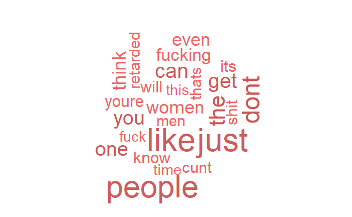

```r
hateful <- rawDF %>% filter(hate_speech_idx == "hateful") # I replaced "n/a" with "hateful" to make the code run
normal <- rawDF %>% filter(hate_speech_idx == "normal") # I replaced "n/a"with "normal" to make the code run

wordcloud(hateful$text, max.words = 25, scale = c(4, 0.8), colors= c("indianred1","indianred2","indianred3","indianred"))
```

```
transformation drops documentstransformation drops documents
```

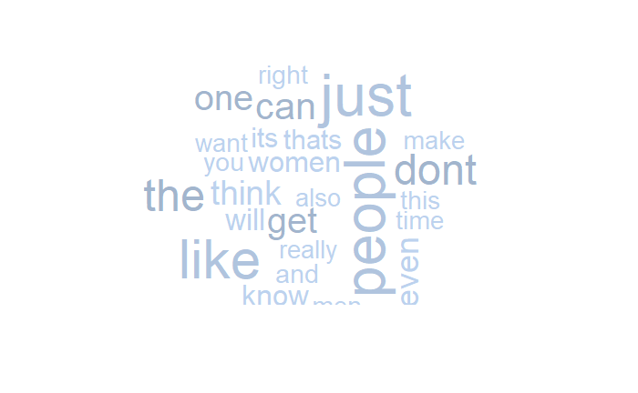

```r
wordcloud(normal$text, max.words = 25, scale = c(4, 0.8), colors= c("lightsteelblue1","lightsteelblue2","lightsteelblue3","lightsteelblue"))
```

There is quite some differences between the normal and hateful coversation.

## Data Preparation

In Data Preparation, I create a corpus to refer to a collection of text documents.

```r
rawCorpus <- Corpus(VectorSource(rawDF$text))
inspect(rawCorpus[1:3])
```

```
<<SimpleCorpus>>
Metadata:  corpus specific: 1, document level (indexed): 0
Content:  documents: 3

[1] 1. A subsection of retarded Hungarians? Ohh boy. brace for a livid Bulbasaur coming in here trying to hate a hole in some of her stupider countrymen.\n2. \tHiii. Just got off work. 444 is mainly the typa guys you imagine writing for US stupid sites, but basically they just try to fit in with the…
[2] 1. > "y'all hear sumn?"  by all means I live in a small town rn (for work). 5k people here, originally a mining community. No one is protesting here. Nobody mentioned the protest today. Nobody here cares, they're busy loving their family and working hard.  Thank god for the electoral college. Li…
[3] 1. wouldn't the defenders or whatever they are as a group be the most diverse group ? Since you know it has a blind dude ,  orphan , black man , woman  and all of their supporting cast ?   &#x200B;  I also believe all the Marvel stuff is going to get canceled on Netflix because next year Disney …
```

The corpus contains 5020 documents, which obviously matches with the number of rows in our dataset.

I will use the function tm_map() to do some first cleaning up. In this case, I change everything to lowerccase and remove the numbers, stopwords, and punctuation as these are not meaningful in detecting the speech hateful or not.

```r
cleanCorpus <- rawCorpus %>% tm_map(tolower) %>% tm_map(removeNumbers)
```

```
transformation drops documentstransformation drops documents
```

```r
cleanCorpus <- cleanCorpus %>% tm_map(tolower) %>% tm_map(removeWords, stopwords()) %>% tm_map(removePunctuation)
```

```
transformation drops documentstransformation drops documentstransformation drops documents
```

As I have removed a lot of items in the previous steps, there is a lot of space left in blank, so I remove these white space too. Then I inspect the corpus with comparison to the raw version.

```r
cleanCorpus <- cleanCorpus %>% tm_map(stripWhitespace)
```

```
transformation drops documents
```

```r
tibble(Raw = rawCorpus$content[1:3], Clean = cleanCorpus$content[1:3])
```

| Raw | Clean |
| --- | --- |
| 1. A subsection of retarded Hungarians? Ohh boy. brace for a livid Bulbasaur coming in here trying to hate a hole in some of her stupider countrymen.\n2. \tHiii. Just got off work. 444 is mainly the t… | subsection retarded hungarians ohh boy brace livid bulbasaur coming trying hate hole stupider countrymen hiii just got work mainly typa guys imagine writing us stupid sites basically just try fit west… |
| 1. > "y'all hear sumn?" by all means I live in a small town rn (for work). 5k people here, originally a mining community. No one is protesting here. Nobody mentioned the protest today. Nobody here car… | y hear sumn means live small town rn work k people originally mining community one protesting nobody mentioned protest today nobody cares busy loving family working hard thank god electoral college li… |
| 1. wouldn't the defenders or whatever they are as a group be the most diverse group ? Since you know it has a blind dude , orphan , black man , woman and all of their supporting cast ? &#x200B; I also… | defenders whatever group diverse group since know blind dude orphan black man woman supporting cast xb also believe marvel stuff going get canceled netflix next year disney launching streaming platfor… |

After cleaning the texts, I have transformed the conversations to a matrix.

```r
cleanDTM <- cleanCorpus %>% DocumentTermMatrix
inspect(cleanDTM)
```

```
<<DocumentTermMatrix (documents: 5020, terms: 36551)>>
Non-/sparse entries: 368956/183117064
Sparsity           : 100%
Maximal term length: 353
Weighting          : term frequency (tf)
Sample             :
      Terms
Docs   can even get just like one people think will women
  1182  17   14  20   17   24  24     13    12    4     6
  1257   7    9   3    7   14   2     14     9    6     0
  1296   8   19  17   11   13   8     37    15   10     7
  1401   6    6   7   18   18   3     18    17    7     0
  1413  17   10   4    6   12   4     10     4    6    14
  2608  22    4   4    7    9   6     12     8    8     0
  3764  20    6  11    9   14   3     23     4   14     0
  3767  22    4   6    9    8   1      5     5    9    47
  3777   2    9   1    9   12  20     27     5    5     0
  4356  15   13   9   12    7   6     22    11    6    38
```

Before I can start with modeling, I need to split the datasets into train and test sets.

```r
set.seed(1234)
trainIndex <- createDataPartition(rawDF$type, p = .75,
                                  list = FALSE,
                                  times = 1)
head(trainIndex)
```

```
     Resample1
[1,]         2
[2,]         3
[3,]         4
[4,]         5
[5,]         6
[6,]         7
```

```r
# Apply split indices to DF
trainDF <- rawDF[trainIndex, ]
```

```
The `i` argument of ``[`()` can't be a matrix as of tibble 3.0.0.
Convert to a vector.
```

```r
testDF <- rawDF[-trainIndex, ]

# Apply split indices to Corpus
trainCorpus <- cleanCorpus[trainIndex]
testCorpus <- cleanCorpus[-trainIndex]

# Apply split indices to DTM
trainDTM <- cleanDTM[trainIndex, ]
testDTM <- cleanDTM[-trainIndex, ]
```

```r
freqWords <- trainDTM %>% findFreqTerms(10)
trainDTM <-  DocumentTermMatrix(trainCorpus, list(dictionary = freqWords))
testDTM <-  DocumentTermMatrix(testCorpus, list(dictionary = freqWords))
```

I am able to reduce the number to around 5000. I will transform the numerical matrix of word counts into a factor that simply indicates whether the word appears in the document or not.

```r
convert_counts <- function(x) {
  x <- ifelse(x > 0, 1, 0) %>% factor(levels = c(0,1), labels = c("No", "Yes"))
}

nColsDTM <- dim(trainDTM)[2]
trainDTM <- apply(trainDTM, MARGIN = 2, convert_counts)
testDTM <- apply(testDTM, MARGIN = 2, convert_counts)

head(trainDTM[,1:10])
```

```
    Terms
Docs asked based busy  can   cares check clue  college comment community
   1 "Yes" "Yes" "Yes" "Yes" "Yes" "Yes" "Yes" "Yes"   "Yes"   "Yes"
   2 "No"  "No"  "No"  "Yes" "No"  "No"  "No"  "No"    "No"    "No"
   3 "No"  "No"  "No"  "No"  "No"  "No"  "No"  "No"    "No"    "No"
   4 "No"  "Yes" "No"  "Yes" "No"  "No"  "No"  "No"    "No"    "No"
   5 "No"  "No"  "No"  "No"  "No"  "No"  "No"  "No"    "No"    "No"
   6 "No"  "Yes" "No"  "Yes" "No"  "No"  "No"  "No"    "No"    "Yes"
```

## Modeling

Now, I have everything in place to start training the model and evaluate against the test dataset. Finally, I can analyze the performance of the model with a confusion matrix.

```r
nbayesModel <-  naiveBayes(trainDTM, trainDF$type, laplace = 1)

predVec <- predict(nbayesModel, testDTM)
confusionMatrix(predVec, testDF$type, positive = "hateful", dnn = c("Prediction", "True"))
```

```
Confusion Matrix and Statistics

          True
Prediction hateful normal
   hateful     687    147
   normal      274    146

               Accuracy : 0.6643
                 95% CI : (0.6374, 0.6904)
    No Information Rate : 0.7663
    P-Value [Acc > NIR] : 1

                  Kappa : 0.1853

 Mcnemar's Test P-Value : 8.207e-10

            Sensitivity : 0.7149
            Specificity : 0.4983
         Pos Pred Value : 0.8237
         Neg Pred Value : 0.3476
             Prevalence : 0.7663
         Detection Rate : 0.5478
   Detection Prevalence : 0.6651
      Balanced Accuracy : 0.6066

       'Positive' Class : hateful
```